# Week 12: R for Data Analytics - ANOVA

Ziyuan Huang

2026-02-12

**Machine:** MELAW - Windows 10 x64

**Random Seed Set To:** 4591

## Introduction

Welcome to Week 12! Previously, we learned how to compare two groups using t-tests. But what happens when we have three, four, or ten groups?

If we simply ran multiple t-tests for every pair of groups, we would run into the **Familywise Error Rate** (FWER) problem. Every test carries a 5% risk of a False Positive (Type I Error, $\alpha = 0.05$).

Mathematically, the probability of **not** making a Type I error in a single test is $1 - 0.05 = 0.95$. If we run $m$ independent tests, the probability of not making *any* error across all of them is $(0.95)^m$.

Therefore, the probability of making **at least one** error (the Familywise Error Rate) is:

$$P(\text{Familywise Error}) = 1 -
(0.95)^m$$

If you run 3 tests ($m=3$), your risk isn’t 5% anymore—it’s nearly 14%:

$$1 - (0.95)^3 = 1 - 0.857 \approx 0.143
\quad (14.3\%)$$

### Real World Analogy: The H1B Lottery

Let’s look at a real-world example of how probabilities accumulate: The H1B Visa Lottery.

In 2024 (for the FY 2025 cap), the selection rate was approximately **25.6%**. This means in any single year, you have a roughly 74.4% chance of *not* getting selected.

If you apply 3 times (e.g., over your 3-year OPT period), what is the chance you get selected **at least once**? It is *not* simply $25.6\% \times 3 = 76.8\%$.

Using the same probability logic as above:

1. Probability of failing 1 time: $1 - 0.256 = 0.744$
2. Probability of failing 3 times in a row: $(0.744)^3 \approx 0.412$
3. Probability of succeeding at least once: $1 - 0.412 = 0.588$

So, even with 3 attempts, your overall success rate is about **58.8%**.

This is the inverse of the FWER problem. In FWER, we want to *avoid* making an error (a “false success”), but the more tests we run, the more likely we are to make one. In the lottery, we *want* a success, and the more tries we make, the more likely we are to get one—but it never reaches 100%.

**ANOVA (Analysis of Variance)** solves the FWER problem by comparing all means simultaneously in a single “Omnibus” test. It relies on the **F-Ratio** [1].

### Learning Objectives

1. Understand the logic of ANOVA through visualization (SST, SSM, SSR).
2. Conduct a One-Way ANOVA using the `ez` package.
3. Check assumptions (Homogeneity of Variance).
4. Perform Post Hoc tests (Bonferroni) to find specific differences.
5. Calculate Effect Size ($\omega^2$).

### Required Packages

We will use `rio` for data import, `ez` for simple ANOVA execution, `MOTE` for effect sizes, and `ggplot2` for visualization.

```r
if (!require("pacman")) install.packages("pacman")
pacman::p_load(tidyverse, rio, ez, MOTE, ggplot2, gridExtra)
```

## Part 1: The Example (Viagra and Libido)

We will use a classic dataset from Andy Field’s textbook [1]. The research question is simple: **Does Viagra affect libido?**

- **Independent Variable (IV):** Dose (Placebo, Low Dose, High Dose)
- **Dependent Variable (DV):** Libido Score

### Loading and Cleaning Data

```r
# Import data
master <- import("data/viagra.sav")

# Convert 'dose' to a factor with labels
master$dose <- factor(master$dose,
                      levels = c(1, 2, 3),
                      labels = c("Placebo", "Low Dose", "High Dose"))

# Create a participant ID (required for ezANOVA)
master$partno <- 1:nrow(master)

# Calculate Grand Mean and Group Means for visualization
grand_mean <- mean(master$libido)
group_means <- master %>%
  group_by(dose) %>%
  summarize(mean_libido = mean(libido))

# Merge group means back into master for plotting
master <- master %>%
  left_join(group_means, by = "dose")

head(master)
```

|  | person | dose | libido | partno | mean_libido |
| --- | --- | --- | --- | --- | --- |
| 1 | 1 | Placebo | 3 | 1 | 2.2 |
| 2 | 2 | Placebo | 2 | 2 | 2.2 |
| 3 | 3 | Placebo | 1 | 3 | 2.2 |
| 4 | 4 | Placebo | 1 | 4 | 2.2 |
| 5 | 5 | Placebo | 4 | 5 | 2.2 |
| 6 | 6 | Low Dose | 5 | 6 | 3.2 |

## Part 2: The Logic of ANOVA (Visualized)

To understand ANOVA, we need to understand **Variance**. Variance is just the average distance of data points from the mean. ANOVA splits this variance into two parts: “Good Variance” (explained by our experiment) and “Bad Variance” (unexplained noise).

We calculate three types of “Sum of Squares” (SS) to measure this [1].

### 1. Total Sum of Squares (SST) - The “Total Variation”

First, we ignore the groups. We just ask: “How spread out is the data overall?” We measure the distance from **Every Data Point** to the **Grand Mean** (the average of everyone).

$$SST = \sum (x_i - \bar{x}_{grand})^2$$

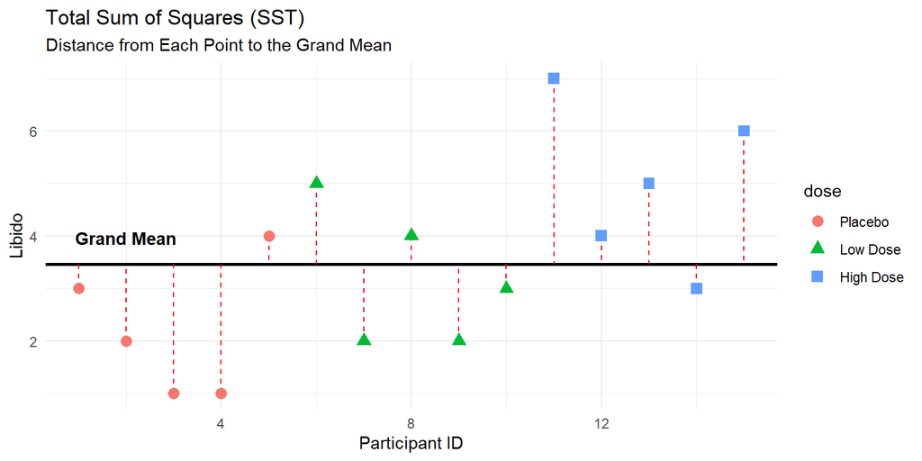

### 2. Model Sum of Squares (SSM) - The “Good Variance”

Now we use our model (the groups). If our experiment worked, the groups should be different. We measure the distance from the **Group Means** to the **Grand Mean**. This represents the **Signal**: How much better is our model (using groups) than just guessing the average?

$$SSM = \sum n_k (\bar{x}_{k} -
\bar{x}_{grand})^2$$

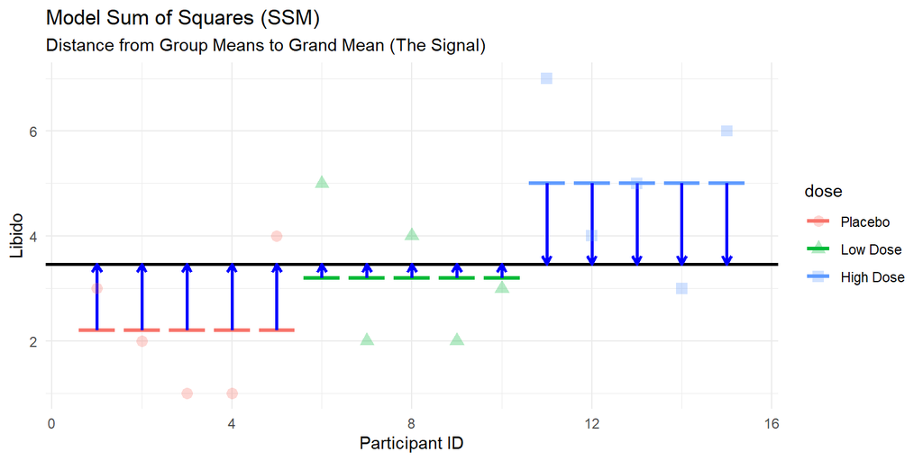

### 3. Residual Sum of Squares (SSR) - The “Bad Variance”

Finally, we look at what we couldn’t explain. Even within the “High Dose” group, not everyone has the same libido. We measure the distance from **Every Data Point** to its **Group Mean**. This represents the **Noise** or **Error**.

$$SSR = \sum (x_{ik} - \bar{x}_{k})^2$$

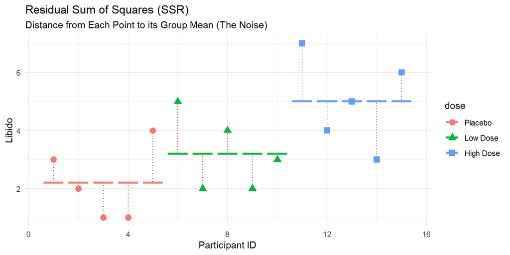

### The F-Ratio Calculation

The F-Ratio is simply the ratio of the “Good Variance” (Signal) to the “Bad Variance” (Noise) [1].

$$F = \frac{\text{Average SSM
(Signal)}}{\text{Average SSR (Noise)}}$$

If $F > 1$, it means the experimental effect is bigger than random noise.

## Part 3: Running ANOVA

We use the `ezANOVA` function from the `ez` package. It is popular because it automatically provides assumption checks and formats the output nicely.

**Key Arguments:** * `dv`: Dependent Variable (Outcome) * `between`: Between-subjects predictor (Group) * `wid`: Within-subject ID (Participant ID) * `type`: Sum of Squares type (Type 3 is standard for social sciences)

```r
options(scipen = 20) # Turn off scientific notation

anova_model <- ezANOVA(data = master,
                       dv = libido,
                       between = dose,
                       wid = partno,
                       type = 3,
                       detailed = TRUE)

print(anova_model)
```

```
## $ANOVA
##        Effect DFn DFd       SSn  SSd         F               p p<.05       ges
## 1 (Intercept)   1  12 180.26667 23.6 91.661017 0.0000005720565     * 0.8842381
## 2        dose   2  12  20.13333 23.6  5.118644 0.0246942895382     * 0.4603659
##
## $`Levene's Test for Homogeneity of Variance`
##   DFn DFd       SSn SSd         F         p p<.05
## 1   2  12 0.1333333 6.8 0.1176471 0.8900225
```

## Part 4: Interpreting Results

### 1. Assumption Check: Levene’s Test

Before looking at the main result, we must check if the groups have equal variances (Homogeneity of Variance).

```r
levene_results <- anova_model$`Levene's Test for Homogeneity of Variance`
print(levene_results)
```

```
##   DFn DFd       SSn SSd         F         p p<.05
## 1   2  12 0.1333333 6.8 0.1176471 0.8900225
```

```r
levene_p <- levene_results$p
```

- **Result:** $p = 0.89$.
- **Interpretation:** Since $p > .05$, the variances are *not* significantly different. We have met the assumption of homogeneity.

### 2. The F-Test (Main Effect)

Now we look at the ANOVA table.

```r
anova_table <- anova_model$ANOVA
print(anova_table)
```

```
##        Effect DFn DFd       SSn  SSd         F               p p<.05       ges
## 1 (Intercept)   1  12 180.26667 23.6 91.661017 0.0000005720565     * 0.8842381
## 2        dose   2  12  20.13333 23.6  5.118644 0.0246942895382     * 0.4603659
```

```r
# Extract values for reporting
# ezANOVA detailed=TRUE includes Intercept, so we filter for "dose"
dose_row <- anova_table[anova_table$Effect == "dose", ]

df_model <- as.numeric(dose_row$DFn)
df_error <- as.numeric(dose_row$DFd)
f_value <- as.numeric(dose_row$F)
p_value <- as.numeric(dose_row$p)
```

- **Result:** $F(2, 12) = 5.12, p = 0.025$.
- **Interpretation:** Since $p < .05$, there is a significant difference in libido somewhere among the three groups. The model (signal) explains significantly more variance than the residuals (noise).

## Part 5: Post Hoc Tests

The ANOVA is an “Omnibus” test—it tells us *that* there is a difference, but not *where*. To find out which specific groups differ (e.g., High Dose vs. Placebo), we run **Post Hoc Tests**.

We use the **Bonferroni correction** to adjust our p-values and keep the Familywise Error Rate at 5%.

```r
posthoc <- pairwise.t.test(master$libido,
                         master$dose,
                         p.adjust.method = "bonferroni",
                         paired = FALSE,
                         var.equal = TRUE)
print(posthoc)
```

```
##
##  Pairwise comparisons using t tests with pooled SD
##
## data:  master$libido and master$dose
##
##           Placebo Low Dose
## Low Dose  0.845   -
## High Dose 0.025   0.196
##
## P value adjustment method: bonferroni
```

```r
# Extract p-values (The matrix has rows: Low Dose, High Dose; cols: Placebo, Low Dose)
p_high_vs_placebo <- posthoc$p.value["High Dose", "Placebo"]
p_low_vs_placebo <- posthoc$p.value["Low Dose", "Placebo"]
p_high_vs_low <- posthoc$p.value["High Dose", "Low Dose"]
```

**Interpretation:** * **High Dose vs. Placebo:** $p = 0.025$ (Significant!) * **Low Dose vs. Placebo:** $p = 0.845$ (Not significant) * **High Dose vs. Low Dose:** $p = 0.196$ (Not significant)

Conclusion: High Dose Viagra significantly increases libido compared to Placebo, but Low Dose does not.

## Part 6: Effect Size

Statistical significance ($p < .05$) depends on sample size. To know how *large* the effect is, we calculate **Omega Squared ($\omega^2$)**.

```r
# Calculate Omega Squared using dynamic values extracted earlier
# df_model = `r df_model`
# df_error = `r df_error`
# f_value = `r f_value`
effect <- omega.F(dfm = df_model, dfe = df_error, Fvalue = f_value, n = nrow(master)/3, a = .05)

omega_sq <- effect$omega
```

[output not shown]

## Part 7: Trend Analysis

When our groups have a natural order (e.g., **Placebo < Low Dose < High Dose**), we can ask a more specific question than just “Are they different?” We can ask: **“What is the shape of the relationship?”**

This is called **Trend Analysis**. We typically test for two main shapes:

1. **Linear Trend (L)**: A straight line.
   - **Logic**: As the dose goes up, libido goes up (or down) consistently.
   - **Analogy**: Like climbing a ramp.
   - **Hypothesis**: “More drug = More effect.”
2. **Quadratic Trend (Q)**: A curve (U-shape or Inverted-U).
   - **Logic**: The effect goes up for a while, but then might level off or even go down at very high doses.
   - **Analogy**: Like throwing a ball—it goes up, peaks, and comes down.
   - **Hypothesis**: “There is a ‘sweet spot’ dose, and too much might be bad (or just not better).”

```r
# Create a copy for trend analysis
master$dose_trend <- master$dose

# Set polynomial contrasts (Linear and Quadratic)
contrasts(master$dose_trend) <- contr.poly(3)

# Run Analysis of Variance (aov is base R function)
trend_model <- aov(libido ~ dose_trend, data = master)
trend_summary <- summary.lm(trend_model)
trend_summary
```

```
##
## Call:
## aov(formula = libido ~ dose_trend, data = master)
##
## Residuals:
##    Min     1Q Median     3Q    Max
##   -2.0   -1.2   -0.2    0.9    2.0
##
## Coefficients:
##              Estimate Std. Error t value    Pr(>|t|)
## (Intercept)    3.4667     0.3621   9.574 0.000000572 ***
## dose_trend.L   1.9799     0.6272   3.157     0.00827 **
## dose_trend.Q   0.3266     0.6272   0.521     0.61201
## ---
## Signif. codes:  0 '***' 0.001 '**' 0.01 '*' 0.05 '.' 0.1 ' ' 1
##
## Residual standard error: 1.402 on 12 degrees of freedom
## Multiple R-squared:  0.4604, Adjusted R-squared:  0.3704
## F-statistic: 5.119 on 2 and 12 DF,  p-value: 0.02469
```

```r
# Extract P-values for dynamic reporting
p_linear <- trend_summary$coefficients["dose_trend.L", "Pr(>|t|)"]
p_quad <- trend_summary$coefficients["dose_trend.Q", "Pr(>|t|)"]
```

### Interpretation of Results

- **Linear Trend (L):** Significant ($p = 0.008$).
  - **Meaning**: Since $p < .05$, we are confident that there is a straight-line relationship.
  - **In Plain English**: As we increase the dose of Viagra from Placebo to Low to High, libido scores consistently increase. The line on a graph would go **straight up**.
- **Quadratic Trend (Q):** Not Significant ($p = 0.612$).
  - **Meaning**: Since $p > .05$, there is no significant curve.
  - **In Plain English**: The data does not go up and then down (or down and then up). It’s just a steady increase.

**Why does this matter?** If the Quadratic Trend *was* significant, it would tell us something important: maybe “High Dose” isn’t actually better than “Low Dose” (maybe it causes side effects that lower libido). But here, the Linear Trend wins: **More is Better** (statistically speaking, for this dataset!).

## Part 8: Final Visualization

Finally, we will create a publication-quality visualization. Instead of just showing the means (bars), we should show the **distribution** of the data.

- **Boxplots**: Show the median and spread (quartiles).
- **Jittered Points**: Show the actual individual participants (raw data).
- **Diamonds**: Show the Group Means.

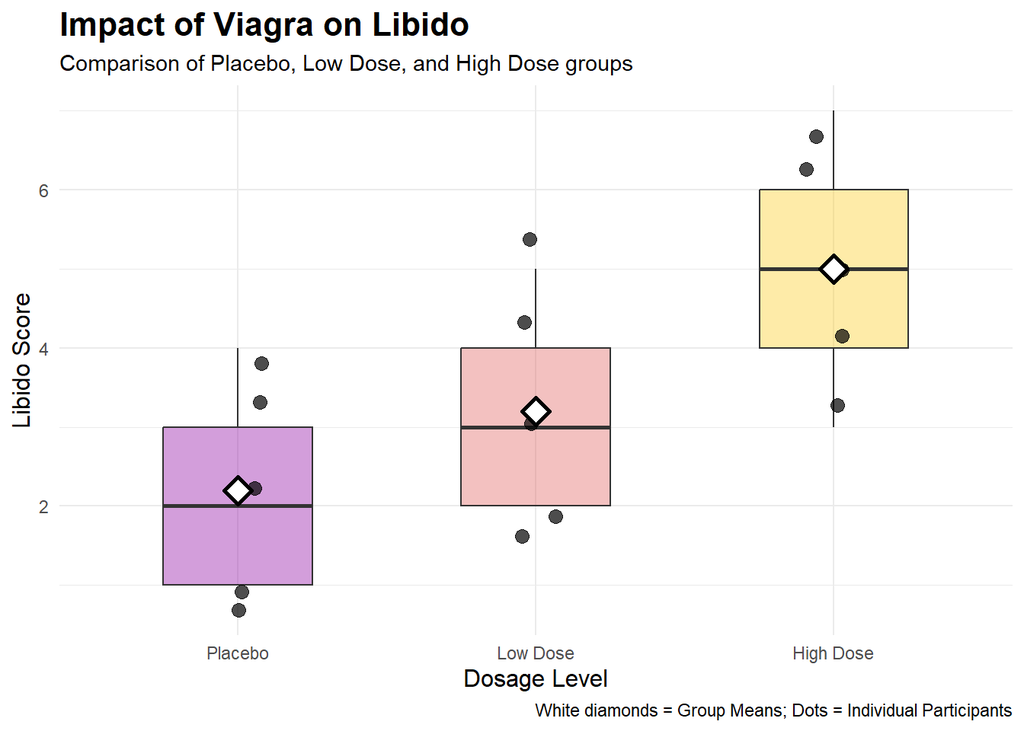

```r
ggplot(master, aes(x = dose, y = libido, fill = dose)) +
  # 1. Boxplot with transparency (alpha) so we can see points
  geom_boxplot(alpha = 0.4, outlier.shape = NA, width = 0.5) +

  # 2. Add Jittered Points (Individual Participants)
  # Jitter adds random noise to x-axis so points don't overlap
  geom_jitter(width = 0.1, size = 3, alpha = 0.7) +

  # 3. Add Mean Points (White Diamonds)
  stat_summary(fun = mean, geom = "point", shape = 23, size = 4,
               fill = "white", color = "black", stroke = 1.5) +

  # 4. Make it colorful and clean
  scale_fill_viridis_d(option = "plasma", begin = 0.3, end = 0.9) +
  theme_minimal() +
  labs(x = "Dosage Level",
       y = "Libido Score",
       title = "Impact of Viagra on Libido",
       subtitle = "Comparison of Placebo, Low Dose, and High Dose groups",
       caption = "White diamonds = Group Means; Dots = Individual Participants") +
  theme(legend.position = "none",
        plot.title = element_text(size = 16, face = "bold"),
        axis.title = element_text(size = 12))
```

## Summary

### References

[1] A. Field, J. Miles, and Z. Field, “Comparing Several Means: ANOVA (GLM 1),” in *Discovering Statistics Using R*. London: SAGE Publications, 2012, ch. 10.